# 12-TidyData

Augusto de Souza Cavalcanti

27/04/2021

## 12.2 Tidy Data

O foco desse capítulo é no pacote tidyr, e o conceito de tidy data.

Podemos apresentar os mesmos dados de diversas maneiras diferentes, abaixo temos os mesmos dados apresentados de 4 maneiras diferentes.

```r
table1
```

```
## # A tibble: 6 x 4
##   country      year  cases population
##   <chr>       <int>  <int>      <int>
## 1 Afghanistan  1999    745   19987071
## 2 Afghanistan  2000   2666   20595360
## 3 Brazil       1999  37737  172006362
## 4 Brazil       2000  80488  174504898
## 5 China        1999 212258 1272915272
## 6 China        2000 213766 1280428583
```

```r
table2
```

```
## # A tibble: 12 x 4
##    country      year type            count
##    <chr>       <int> <chr>           <int>
##  1 Afghanistan  1999 cases             745
##  2 Afghanistan  1999 population   19987071
##  3 Afghanistan  2000 cases            2666
##  4 Afghanistan  2000 population   20595360
##  5 Brazil       1999 cases           37737
##  6 Brazil       1999 population  172006362
##  7 Brazil       2000 cases           80488
##  8 Brazil       2000 population  174504898
##  9 China        1999 cases          212258
## 10 China        1999 population 1272915272
## 11 China        2000 cases          213766
## 12 China        2000 population 1280428583
```

```r
table3
```

```
## # A tibble: 6 x 3
##   country      year rate
## * <chr>       <int> <chr>
## 1 Afghanistan  1999 745/19987071
## 2 Afghanistan  2000 2666/20595360
## 3 Brazil       1999 37737/172006362
## 4 Brazil       2000 80488/174504898
## 5 China        1999 212258/1272915272
## 6 China        2000 213766/1280428583
```

```r
table4a
```

```
## # A tibble: 3 x 3
##   country     `1999` `2000`
## * <chr>        <int>  <int>
## 1 Afghanistan    745   2666
## 2 Brazil       37737  80488
## 3 China       212258 213766
```

```r
table4b
```

```
## # A tibble: 3 x 3
##   country         `1999`     `2000`
## * <chr>            <int>      <int>
## 1 Afghanistan   19987071   20595360
## 2 Brazil       172006362  174504898
## 3 China       1272915272 1280428583
```

Todos são representações dos mesmos dados mas nem todos tem a mesma facilidade para uso. Um dos datasets, o no formato tidy, pode ser usado com muito mais facilidade dentro do tidyverse.

Um dataset é considerado tidy se segue três regras:

1- Cada variável tem sua coluna

2- Cada observação tem sua linha

3- Cada valor tem sua célula

O único dataset que era tidy no exemplo anterior era o da table1.

Vantagens de tidy data:

- Manter a maneira de armazenar dados consistentes facilita o aprendizado e uso por manter tudo uniforme.
- Existe uma vantegem dos dados em colunas pois permite a natureza vetorial do r ser aproeveitada. Dessa maneira a transformação de dados tidy se torna natural.

Todos pacotes do tidyverse foram planejados para serem usados com tidy data. Dessa forma é importante manter os dados dessa maneira.

### Exercícios 12.2.1

1. Escreva como as variáveis e observações estão em cada uma das tabelas acima.

table1 = Dados Limpos (tidy), cada linha uma observação, cada coluna uma variável e cada célula um valor.

table2 = Cada observação está em 2 linhas, existe uma coluna que indica o que está sendo observado naquela linha

table3 = Cada observação em sua linha, porém existe uma coluna para duas variáveis.

table4a e table4b = As tabelas estão cada uma separada para descrever uma variável, o ano está divido em colunas dessa maneira uma linha não apresenta uma observação, nem uma coluna uma variável.

2. Calcule o rate (casos por 10 000), para table 2 e tables 4:

```r
table2_casos <- table2 %>% filter(type=='cases') %>% rename(cases=count) %>% select(country,year,cases)

table2_pop <- table2 %>% filter(type=='population') %>% rename(population=count) %>% select(country,year,population)

table2_nova <- tibble(country= table2_casos$country, year=table2_casos$year, casos=table2_casos$cases, populacao = table2_pop$population) %>% mutate(prop= casos/populacao*10000) %>% select(country,year,prop)

# agora para armazenar na tabela antiga:

table2_aux <- table2_nova %>% mutate(type='cases_per_10000') %>% rename(count =prop)

table_2_nova <- bind_rows(table2,table2_aux)

table_2_nova %>% arrange(country,year,type,count)
```

```
## # A tibble: 18 x 4
##    country      year type              count
##    <chr>       <int> <chr>             <dbl>
##  1 Afghanistan  1999 cases           7.45e+2
##  2 Afghanistan  1999 cases_per_10000 3.73e-1
##  3 Afghanistan  1999 population      2.00e+7
##  4 Afghanistan  2000 cases           2.67e+3
##  5 Afghanistan  2000 cases_per_10000 1.29e+0
##  6 Afghanistan  2000 population      2.06e+7
##  7 Brazil       1999 cases           3.77e+4
##  8 Brazil       1999 cases_per_10000 2.19e+0
##  9 Brazil       1999 population      1.72e+8
## 10 Brazil       2000 cases           8.05e+4
## 11 Brazil       2000 cases_per_10000 4.61e+0
## 12 Brazil       2000 population      1.75e+8
## 13 China        1999 cases           2.12e+5
## 14 China        1999 cases_per_10000 1.67e+0
## 15 China        1999 population      1.27e+9
## 16 China        2000 cases           2.14e+5
## 17 China        2000 cases_per_10000 1.67e+0
## 18 China        2000 population      1.28e+9
```

Para o outro caso:

```r
table4c <- tibble(country =table4a$country,`1999`= table4a$`1999` / table4b$`1999` * 10000,
                  `2000` = table4a$`2000` / table4b$`2000` * 10000)
```

O caso da tabela 4 é um pouco mais fácil mas ambos poderiam ser bem melhores.

3. Crie um gráfico mostrando os casos em relação ao tempo a partir da tabela 2.

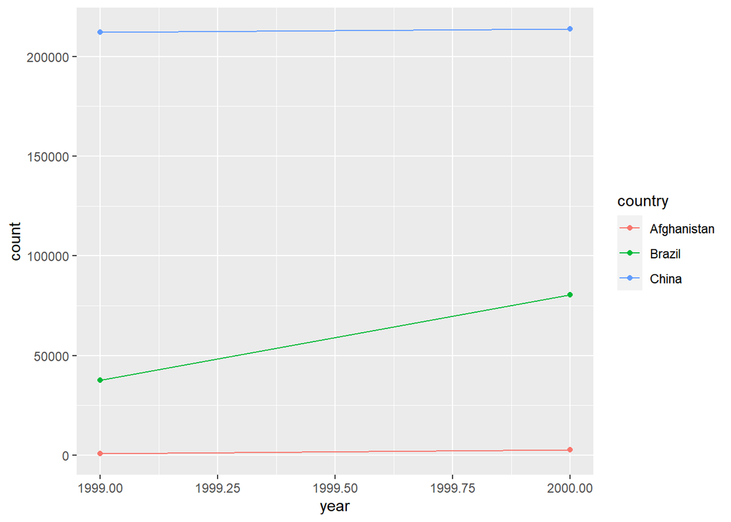

```r
table2 %>% filter(type=='cases') %>% ggplot(aes(year,count)) + geom_line(aes(color=country))+ geom_point(aes(color=country))
```

## 12.3 Tidy Data

A maioria dos dados que encontramos não está tidy. Os dois principais motivos são:

- A maioria das pessoas não está familiarizado com o conceito de tidy data.
- Os dados muitas vezes estão organizados para outro propósito sem ser a análise, Por exemplo para facilitar a entrada de dados.

Isso significa que quase sempre temos que fazer a limpeza desses dados. O primeiro passo é descobrir o que são variáveis e o que são observações. O segundo passo é resolver um de dois problemas:

- Uma variável pode estar distríbuida em várias colunas.
- Uma observação pode estar em várias linhas.

Para resolver isso você deve usar duas das mais importantes funções do tidyr: pivot_longer() e pivot_wider().

### 12.3.1 Longer

Um problema comum é que os nomes das colunas não são variáveis mas sim valores de variáveis. Na table4a por exemplo, as colunas 1999 e 2000 são valores de uma variável ano e os valores dessas colunas são os valores de uma variável casos, e cada linha representa duas observações, não uma.

```r
table4a
```

```
## # A tibble: 3 x 3
##   country     `1999` `2000`
## * <chr>        <int>  <int>
## 1 Afghanistan    745   2666
## 2 Brazil       37737  80488
## 3 China       212258 213766
```

Para fazer a limpeza desses dados precisamos pivotear as colunas para se tornarem um novo par de variáveis. Precisamos de 3 parâmetros para descrever esse processo:

- As colunas que os nomes são valores e não variáveis. (1999 e 2000)
- O nome da variável que conterá o nome das colunas atuais. (year)
- O nome da variável que conterá o valor presente nas colunas atualmente. (cases)

```r
(tidy4a <- table4a %>% pivot_longer(cols=c(`1999`,`2000`),names_to = 'year',values_to = 'cases'))
```

```
## # A tibble: 6 x 3
##   country     year   cases
##   <chr>       <chr>  <int>
## 1 Afghanistan 1999     745
## 2 Afghanistan 2000    2666
## 3 Brazil      1999   37737
## 4 Brazil      2000   80488
## 5 China       1999  212258
## 6 China       2000  213766
```

As colunas para pivotear são selecionadas com uma notação igual ao select do dplyr, porém como nesse caso só tinhamos duas listamos individualmente.

Podemos usar pivot_longer() no dataset 4b também.

```r
(tidy4b <- table4b %>% pivot_longer(cols=c(`1999`,`2000`),names_to = 'year', values_to='population'))
```

```
## # A tibble: 6 x 3
##   country     year  population
##   <chr>       <chr>      <int>
## 1 Afghanistan 1999    19987071
## 2 Afghanistan 2000    20595360
## 3 Brazil      1999   172006362
## 4 Brazil      2000   174504898
## 5 China       1999  1272915272
## 6 China       2000  1280428583
```

Para combinar as duas tabelas e tornar o dataset tidy e único podemos fazer um left_join(), veremos mais sobre isso em relational data mas é estilo SQL.

```r
left_join(tidy4a,tidy4b)
```

```
## # A tibble: 6 x 4
##   country     year   cases population
##   <chr>       <chr>  <int>      <int>
## 1 Afghanistan 1999     745   19987071
## 2 Afghanistan 2000    2666   20595360
## 3 Brazil      1999   37737  172006362
## 4 Brazil      2000   80488  174504898
## 5 China       1999  212258 1272915272
## 6 China       2000  213766 1280428583
```

### 12.3.2 Wider

O oposto de pivot_longer(), pivot_wider(), é usado para quando temos uma observação dividida em várias linhas. Na table2 por exemplo onde uma observação é um país em um ano mas isso está representado em várias 2 linhas.

```r
table2
```

```
## # A tibble: 12 x 4
##    country      year type            count
##    <chr>       <int> <chr>           <int>
##  1 Afghanistan  1999 cases             745
##  2 Afghanistan  1999 population   19987071
##  3 Afghanistan  2000 cases            2666
##  4 Afghanistan  2000 population   20595360
##  5 Brazil       1999 cases           37737
##  6 Brazil       1999 population  172006362
##  7 Brazil       2000 cases           80488
##  8 Brazil       2000 population  174504898
##  9 China        1999 cases          212258
## 10 China        1999 population 1272915272
## 11 China        2000 cases          213766
## 12 China        2000 population 1280428583
```

Para alterarmos precisamos de dois parâmetros:

- A coluna para tirar os nomes das variáveis. (type)
- A coluna para tirar os valores das variáveis. (count)

```r
table2 %>% pivot_wider(names_from = type,values_from = count)
```

```
## # A tibble: 6 x 4
##   country      year  cases population
##   <chr>       <int>  <int>      <int>
## 1 Afghanistan  1999    745   19987071
## 2 Afghanistan  2000   2666   20595360
## 3 Brazil       1999  37737  172006362
## 4 Brazil       2000  80488  174504898
## 5 China        1999 212258 1272915272
## 6 China        2000 213766 1280428583
```

Os dois tipos de pivoteamento se complementam e são usados frequentemente.

### Exercícios 12.3.3

1. Por que pivot_wider e pivot_longer não são perfeitamente símetricas? considere o ex a seguir:

```r
stocks <- tibble(
  year   = c(2015, 2015, 2016, 2016),
  half  = c(   1,    2,     1,    2),
  return = c(1.88, 0.59, 0.92, 0.17)
)
stocks %>%
  pivot_wider(names_from = year, values_from = return) %>%
  pivot_longer(`2015`:`2016`, names_to = "year", values_to = "return")
```

```
## # A tibble: 4 x 3
##    half year  return
##   <dbl> <chr>  <dbl>
## 1     1 2015    1.88
## 2     1 2016    0.92
## 3     2 2015    0.59
## 4     2 2016    0.17
```

Os tipos das colunas são perdidos quando fazemos algumas dessas transformações. O argumento names_ptypes permite passar o tipo de cada coluna por meio de seus nomes.

2. Por que esse códigonão funciona?

```r
# table4a %>%
#   pivot_longer(c(1999,2000), names_to = "year", values_to = "cases")
```

O código falha pois 1999 e 2000 devem conter backsticks pois são nomes “impróprios”.

3. O que aconteceria se voce usase pivot_wider nessa tabela? Por que? Como você poderia adicionar uma nova coluna para indentificar unicamente cada valor?

```r
people <- tribble(
  ~name,             ~names,  ~values,
  #-----------------|--------|------
  "Phillip Woods",   "age",       45,
  "Phillip Woods",   "height",   186,
  "Phillip Woods",   "age",       50,
  "Jessica Cordero", "age",       37,
  "Jessica Cordero", "height",   156
)
```

Tentar falar um pivot wider dess table falha pois não teriamos uma idade repetida para phillip, para resolver isso teriamos que adicionar um índice para cada pessoa, e depois de alterado isso seria usado como chave primária.

```r
people %>% mutate(id = c(1,1,2,3,3)) %>% pivot_wider(names_from = names,values_from=values) %>% arrange(id,name,age,height)
```

```
## # A tibble: 3 x 4
##   name               id   age height
##   <chr>           <dbl> <dbl>  <dbl>
## 1 Phillip Woods       1    45    186
## 2 Phillip Woods       2    50     NA
## 3 Jessica Cordero     3    37    156
```

Se fosse um erro de entrada bastaria remover o valor incorreto do phillip.

4. Limpe os simples dados a seguir. Eles devem ser alongados ou alargados?

```r
preg <- tribble(
  ~pregnant, ~male, ~female,
  "yes",     NA,    10,
  "no",      20,    12
)
```

Sem muito conhecimento sobre o dataframe podemos considerar que os valores das colunas male e female são contagens de cada um e que male e female seriam valores para a variável sexo. Temos que usar pivor_longer.

```r
preg %>% pivot_longer(cols = c(male,female),names_to = 'Sex',values_to = 'Count')
```

```
## # A tibble: 4 x 3
##   pregnant Sex    Count
##   <chr>    <chr>  <dbl>
## 1 yes      male      NA
## 2 yes      female    10
## 3 no       male      20
## 4 no       female    12
```

## 12.4 Separating and Uniting

Até agora aprendemos a limpar a tabela 2 e 4 mas não a 3. Essa contém um problema diferente, os dados sobre população e casos estão na mesma célula dividos por uma barra. Uma coluna contém duas variáveis. Para consertar esse problema temos que usar a função separate(). Também existe um complemento para essa função que se chama unite().

### 12.4.1 Separate

separate separa uma coluna em diversas fazendo isso por meio do separador definido.

```r
table3
```

```
## # A tibble: 6 x 3
##   country      year rate
## * <chr>       <int> <chr>
## 1 Afghanistan  1999 745/19987071
## 2 Afghanistan  2000 2666/20595360
## 3 Brazil       1999 37737/172006362
## 4 Brazil       2000 80488/174504898
## 5 China        1999 212258/1272915272
## 6 China        2000 213766/1280428583
```

A coluna rate contém dados sobre os casos e população do país naquele ano, para que os dados sejam tidy, não podemos ter valores de duas variáveis em uma célula. Fazemos a separação por separate com o separator / que é o que separa esses dados.

```r
table3 %>% separate(col = rate, into=c('cases','population'), sep='/')
```

```
## # A tibble: 6 x 4
##   country      year cases  population
##   <chr>       <int> <chr>  <chr>
## 1 Afghanistan  1999 745    19987071
## 2 Afghanistan  2000 2666   20595360
## 3 Brazil       1999 37737  172006362
## 4 Brazil       2000 80488  174504898
## 5 China        1999 212258 1272915272
## 6 China        2000 213766 1280428583
```

Por padrão essa função já separa quando encontra um valor que não é número ou letra. Mas podemos fornecer o separador.

Podemos perceber que as colunas foram classificadas como vetores de caracteres, para que o tipo já seja indentificado automaticamente temos que passar o argumento convert= T.

```r
table3 %>% separate(col = rate, into=c('cases','population'), sep='/',convert=T)
```

```
## # A tibble: 6 x 4
##   country      year  cases population
##   <chr>       <int>  <int>      <int>
## 1 Afghanistan  1999    745   19987071
## 2 Afghanistan  2000   2666   20595360
## 3 Brazil       1999  37737  172006362
## 4 Brazil       2000  80488  174504898
## 5 China        1999 212258 1272915272
## 6 China        2000 213766 1280428583
```

Você pode separar também baseado em posição se passarmos um valor númerico para sep.

```r
tb3n <- table3 %>% separate(col=year,into=c('Century','Year'),sep=2)
```

### 12.4.2 Unite

Unite faz o inverso do separate, costuma ser menos frequente a necessidade de usar mas é útil saber.

```r
table5
```

```
## # A tibble: 6 x 4
##   country     century year  rate
## * <chr>       <chr>   <chr> <chr>
## 1 Afghanistan 19      99    745/19987071
## 2 Afghanistan 20      00    2666/20595360
## 3 Brazil      19      99    37737/172006362
## 4 Brazil      20      00    80488/174504898
## 5 China       19      99    212258/1272915272
## 6 China       20      00    213766/1280428583
```

```r
table5 %>% unite(new,century,year,sep='')
```

```
## # A tibble: 6 x 3
##   country     new   rate
##   <chr>       <chr> <chr>
## 1 Afghanistan 1999  745/19987071
## 2 Afghanistan 2000  2666/20595360
## 3 Brazil      1999  37737/172006362
## 4 Brazil      2000  80488/174504898
## 5 China       1999  212258/1272915272
## 6 China       2000  213766/1280428583
```

### Exericícios 12.4.3

1. O que os argumentos extra e fill fazem no separate. Use os dataframes a seguir para testar.

Extra:

```r
tibble(x = c("a,b,c", "d,e,f,g", "h,i,j")) %>%
  separate(x, c("one", "two", "three"),extra='warn') # Discarta os valores das linhas que a separação gera mais valores que colunas informadas e deixa um aviso
```

```
## # A tibble: 3 x 3
##   one   two   three
##   <chr> <chr> <chr>
## 1 a     b     c
## 2 d     e     f
## 3 h     i     j
```

```r
tibble(x = c("a,b,c", "d,e,f,g", "h,i,j")) %>%
  separate(x, c("one", "two", "three"),extra = 'drop') # Discarta os valores das linhas que a separação gera mais valores que colunas informadas e não avisa
```

```
## # A tibble: 3 x 3
##   one   two   three
##   <chr> <chr> <chr>
## 1 a     b     c
## 2 d     e     f
## 3 h     i     j
```

```r
tibble(x = c("a,b,c", "d,e,f,g", "f,g,i")) %>%
  separate(x, c("one", "two", "three"),extra='merge') # Os valores das linhas que tem mais valores ao separar que colunas informadas juntam na ultima célula
```

```
## # A tibble: 3 x 3
##   one   two   three
##   <chr> <chr> <chr>
## 1 a     b     c
## 2 d     e     f,g
## 3 f     g     i
```

Fill:

```r
tibble(x = c("a,b,c", "d,e", "f,g,i")) %>%
  separate(x, c("one", "two", "three"),fill='warn') # Preenche os valores para a direita com NA e deixa um aviso
```

```
## # A tibble: 3 x 3
##   one   two   three
##   <chr> <chr> <chr>
## 1 a     b     c
## 2 d     e     <NA>
## 3 f     g     i
```

```r
tibble(x = c("a,b,c", "d,e", "f,g,i")) %>%
  separate(x, c("one", "two", "three"),fill='right') # Preenche os valores NA para a direita e não avisa
```

```
## # A tibble: 3 x 3
##   one   two   three
##   <chr> <chr> <chr>
## 1 a     b     c
## 2 d     e     <NA>
## 3 f     g     i
```

```r
tibble(x = c("a,b,c", "d,e", "f,g,i")) %>%
  separate(x, c("one", "two", "three"),fill='left') # Preenche os valores NA na esquerda e não deixa aviso.
```

```
## # A tibble: 3 x 3
##   one   two   three
##   <chr> <chr> <chr>
## 1 a     b     c
## 2 <NA>  d     e
## 3 f     g     i
```

2. O que o argumento remove de unite() e separate() faz? Por que você colocaria em falso?

O argumento remove é para defeinir se você deseja tirar a coluna de input ou manter ela junto com as que foram geradas.

```r
table3 %>% separate(year,c('Seculo','Ano'),sep=2,remove = F)
```

```
## # A tibble: 6 x 5
##   country      year Seculo Ano   rate
##   <chr>       <int> <chr>  <chr> <chr>
## 1 Afghanistan  1999 19     99    745/19987071
## 2 Afghanistan  2000 20     00    2666/20595360
## 3 Brazil       1999 19     99    37737/172006362
## 4 Brazil       2000 20     00    80488/174504898
## 5 China        1999 19     99    212258/1272915272
## 6 China        2000 20     00    213766/1280428583
```

Pode ser útil em situações como no exemplo acima que queremos separar em duas colunas mas manter a original.

3. A diferença de separate e extract é que extract faz a separação por meio do regex e te da mais liberdade para fazer as separações.

## 12.5 Missing Values

Existem duas maneiras de representar dados faltantes em um dataset:

- Explicitamente: Representar com NA
- Implicitamente: Os faltantes não estão presentes nos dados

Exemplo a seguir:

```r
stocks <- tibble(
  year   = c(2015, 2015, 2015, 2015, 2016, 2016, 2016),
  qtr    = c(   1,    2,    3,    4,    2,    3,    4),
  return = c(1.88, 0.59, 0.35,   NA, 0.92, 0.17, 2.66)
)
```

Podemos tornar dados missing explicitos em implicitos no pivot longer com o argumento values_drop_na = TRUE

```r
stocks %>%
  pivot_wider(names_from = year, values_from = return)
```

```
## # A tibble: 4 x 3
##     qtr `2015` `2016`
##   <dbl>  <dbl>  <dbl>
## 1     1   1.88  NA
## 2     2   0.59   0.92
## 3     3   0.35   0.17
## 4     4  NA      2.66
```

```r
stocks %>%
  pivot_wider(names_from = year, values_from = return) %>%
  pivot_longer(
    cols = c(`2015`, `2016`),
    names_to = "year",
    values_to = "return",
    values_drop_na = TRUE
  )
```

```
## # A tibble: 6 x 3
##     qtr year  return
##   <dbl> <chr>  <dbl>
## 1     1 2015    1.88
## 2     2 2015    0.59
## 3     2 2016    0.92
## 4     3 2015    0.35
## 5     3 2016    0.17
## 6     4 2016    2.66
```

O argumento complete também explicita os NAs.

```r
stocks
```

```
## # A tibble: 7 x 3
##    year   qtr return
##   <dbl> <dbl>  <dbl>
## 1  2015     1   1.88
## 2  2015     2   0.59
## 3  2015     3   0.35
## 4  2015     4  NA
## 5  2016     2   0.92
## 6  2016     3   0.17
## 7  2016     4   2.66
```

```r
stocks %>%
  complete(year, qtr)
```

```
## # A tibble: 8 x 3
##    year   qtr return
##   <dbl> <dbl>  <dbl>
## 1  2015     1   1.88
## 2  2015     2   0.59
## 3  2015     3   0.35
## 4  2015     4  NA
## 5  2016     1  NA
## 6  2016     2   0.92
## 7  2016     3   0.17
## 8  2016     4   2.66
```

Outra coisa importante de saber é, quando a fonte dos dados é usada primariamente para entrada de dados as vezes NAs significam que os valores anteriores devem ser carregados. EX:

```r
treatment <- tribble(
  ~ person,           ~ treatment, ~response,
  "Derrick Whitmore", 1,           7,
  NA,                 2,           10,
  NA,                 3,           9,
  "Katherine Burke",  1,           4,
  NA,                 2,           7,
)
```

Os NAs representam o primeiro valor acima dele que não é NA. O argumento fill faz esse preenchimento.

```r
treatment %>% fill(person)
```

```
## # A tibble: 5 x 3
##   person           treatment response
##   <chr>                <dbl>    <dbl>
## 1 Derrick Whitmore         1        7
## 2 Derrick Whitmore         2       10
## 3 Derrick Whitmore         3        9
## 4 Katherine Burke          1        4
## 5 Katherine Burke          2        7
```

### Exercícios 12.5.1

2. O que o argumento direction faz para fill?

Decide em que direção sera o preenchimento. Para cima ou para baixo, podemos fazer com o exmplo anterior (Vai ficar errado.)

```r
treatment %>% fill(person,.direction= "up")
```

```
## # A tibble: 5 x 3
##   person           treatment response
##   <chr>                <dbl>    <dbl>
## 1 Derrick Whitmore         1        7
## 2 Katherine Burke          2       10
## 3 Katherine Burke          3        9
## 4 Katherine Burke          1        4
## 5 <NA>                     2        7
```

## 12.6 Case Study

Nessa parte faremos uso de tudo que aprendemos nesse capítulo para tentar limpar dados reais. Para isso usaremos dados sobre tuberculose por ano, pais,idade,genero e método de diagnostico. O banco de dados é o tidyr::who

Esse banco de dados está extremamente confuso, com codificação estranha nas colunas que deveriam ser observações de variáveis.

Primeiro precisamos indentificar o que cada coluna significa:

- Country, iso2 e iso3 representam o nome e códigos do país e são todas variáveis.
- Ano também é variável.
- As outras colunas são valores que representam o grupo e seus valores são o número de casos desses. Primeiro podemos fazer um pivot_longer e unir essas categorias.

```r
(who_nova <- who %>% pivot_longer(new_sp_m014:newrel_f65,names_to = "grupo",values_to = "casos",values_drop_na = T))
```

```
## # A tibble: 76,046 x 6
##    country     iso2  iso3   year grupo        casos
##    <chr>       <chr> <chr> <int> <chr>        <int>
##  1 Afghanistan AF    AFG    1997 new_sp_m014      0
##  2 Afghanistan AF    AFG    1997 new_sp_m1524    10
##  3 Afghanistan AF    AFG    1997 new_sp_m2534     6
##  4 Afghanistan AF    AFG    1997 new_sp_m3544     3
##  5 Afghanistan AF    AFG    1997 new_sp_m4554     5
##  6 Afghanistan AF    AFG    1997 new_sp_m5564     2
##  7 Afghanistan AF    AFG    1997 new_sp_m65       0
##  8 Afghanistan AF    AFG    1997 new_sp_f014      5
##  9 Afghanistan AF    AFG    1997 new_sp_f1524    38
## 10 Afghanistan AF    AFG    1997 new_sp_f2534    36
## # ... with 76,036 more rows
```

Agora fizemos a separação dos grupos, de acordo com os dados sabemos que as 3 primeiras letras indicam se o caso é novo ou antigo, nesse df todos são novos. As próximas letras indicam o método de diagnóstico. A útltima letra indica o sexo da pessoa. Os números indicam a idade das pessoas do grupo. Podemos separar isso em várias colunas.

Os nomes estão inconsistentes, temos newrel e não new_rel conforme o resto dos grupos, alteraremos isso com str_replace do pacote stringr para que todos dados se mantenham consistentes.

```r
who_nova2 <- who_nova %>% mutate(grupo = str_replace(grupo,'newrel','new_rel'))
```

Podemos separar esses grupos em dois passos, primeiro por underscore:

```r
(who_nova3 <- who_nova2 %>% separate(grupo,c('novo','diagnóstico','sexoidade')))
```

```
## # A tibble: 76,046 x 8
##    country     iso2  iso3   year novo  diagnóstico sexoidade casos
##    <chr>       <chr> <chr> <int> <chr> <chr>       <chr>     <int>
##  1 Afghanistan AF    AFG    1997 new   sp          m014          0
##  2 Afghanistan AF    AFG    1997 new   sp          m1524        10
##  3 Afghanistan AF    AFG    1997 new   sp          m2534         6
##  4 Afghanistan AF    AFG    1997 new   sp          m3544         3
##  5 Afghanistan AF    AFG    1997 new   sp          m4554         5
##  6 Afghanistan AF    AFG    1997 new   sp          m5564         2
##  7 Afghanistan AF    AFG    1997 new   sp          m65           0
##  8 Afghanistan AF    AFG    1997 new   sp          f014          5
##  9 Afghanistan AF    AFG    1997 new   sp          f1524        38
## 10 Afghanistan AF    AFG    1997 new   sp          f2534        36
## # ... with 76,036 more rows
```

Agora podemos separar sexo e idade.

```r
(who_nova4 <- who_nova3 %>% separate(sexoidade,c('sexo','idade'),sep=1))
```

```
## # A tibble: 76,046 x 9
##    country     iso2  iso3   year novo  diagnóstico sexo  idade casos
##    <chr>       <chr> <chr> <int> <chr> <chr>       <chr> <chr> <int>
##  1 Afghanistan AF    AFG    1997 new   sp          m     014       0
##  2 Afghanistan AF    AFG    1997 new   sp          m     1524     10
##  3 Afghanistan AF    AFG    1997 new   sp          m     2534      6
##  4 Afghanistan AF    AFG    1997 new   sp          m     3544      3
##  5 Afghanistan AF    AFG    1997 new   sp          m     4554      5
##  6 Afghanistan AF    AFG    1997 new   sp          m     5564      2
##  7 Afghanistan AF    AFG    1997 new   sp          m     65        0
##  8 Afghanistan AF    AFG    1997 new   sp          f     014       5
##  9 Afghanistan AF    AFG    1997 new   sp          f     1524     38
## 10 Afghanistan AF    AFG    1997 new   sp          f     2534     36
## # ... with 76,036 more rows
```

Podemos agora discartar new , iso2 e iso3 pois são desnecessários no dataset.

```r
(who_tidy <- who_nova4 %>% select(-iso2,-iso3,-novo))
```

```
## # A tibble: 76,046 x 6
##    country      year diagnóstico sexo  idade casos
##    <chr>       <int> <chr>       <chr> <chr> <int>
##  1 Afghanistan  1997 sp          m     014       0
##  2 Afghanistan  1997 sp          m     1524     10
##  3 Afghanistan  1997 sp          m     2534      6
##  4 Afghanistan  1997 sp          m     3544      3
##  5 Afghanistan  1997 sp          m     4554      5
##  6 Afghanistan  1997 sp          m     5564      2
##  7 Afghanistan  1997 sp          m     65        0
##  8 Afghanistan  1997 sp          f     014       5
##  9 Afghanistan  1997 sp          f     1524     38
## 10 Afghanistan  1997 sp          f     2534     36
## # ... with 76,036 more rows
```

Fizemos isso gradualmente e salvando as variáveis aos poucos, essa maneira não é a mais comum de ser feita mas sim com uma sequência de pipes como a seguir (retirado direto do livro):

```r
who %>%
  pivot_longer(
    cols = new_sp_m014:newrel_f65,
    names_to = "key",
    values_to = "cases",
    values_drop_na = TRUE
  ) %>%
  mutate(
    key = stringr::str_replace(key, "newrel", "new_rel")
  ) %>%
  separate(key, c("new", "var", "sexage")) %>%
  select(-new, -iso2, -iso3) %>%
  separate(sexage, c("sex", "age"), sep = 1)
```

```
## # A tibble: 76,046 x 6
##    country      year var   sex   age   cases
##    <chr>       <int> <chr> <chr> <chr> <int>
##  1 Afghanistan  1997 sp    m     014       0
##  2 Afghanistan  1997 sp    m     1524     10
##  3 Afghanistan  1997 sp    m     2534      6
##  4 Afghanistan  1997 sp    m     3544      3
##  5 Afghanistan  1997 sp    m     4554      5
##  6 Afghanistan  1997 sp    m     5564      2
##  7 Afghanistan  1997 sp    m     65        0
##  8 Afghanistan  1997 sp    f     014       5
##  9 Afghanistan  1997 sp    f     1524     38
## 10 Afghanistan  1997 sp    f     2534     36
## # ... with 76,036 more rows
```

### Exercícios 12.6.1

1. O ideal é que o values_drop_na não fosse aplicado para ficar mais claro essa falta de dados, temos muitos dados faltantes implícitos após fazer a limpeza. NA e zero são completamente diferentes, zero representa que sabemos que não tiveram casos daquele grupo no ano. Enquanto NA significa que não temos informação sobre o número de casos, podem ter acotencido qualquer número de casos.
2. Caso não tivessemos feito a alteração do newrel para new_rel, ao fazer a divisão as colunas que tinham newrel ficariam com a sexo/idade em diagnostico e pelo fato do preenchimento de faltante a direita as colunas sexo e idade ficariam com NA para essses casos.
3. iso2 e iso3 são redundantes, para esse dataset não faz sentido mante-las, porém para um banco de dados com diversas tabelas relacionadas, esses dados podem ser importantes para relalações.
4. Para cada país,ano e sexo calcule o número total de casos. Faça uma visualização de dados informativa sobre isso.

```r
(casos_who_gp <- who_tidy %>% group_by(country,year,sexo) %>% summarise(casostot = sum(casos)))
```

```
## # A tibble: 6,921 x 4
## # Groups:   country, year [3,484]
##    country      year sexo  casostot
##    <chr>       <int> <chr>    <int>
##  1 Afghanistan  1997 f          102
##  2 Afghanistan  1997 m           26
##  3 Afghanistan  1998 f         1207
##  4 Afghanistan  1998 m          571
##  5 Afghanistan  1999 f          517
##  6 Afghanistan  1999 m          228
##  7 Afghanistan  2000 f         1751
##  8 Afghanistan  2000 m          915
##  9 Afghanistan  2001 f         3062
## 10 Afghanistan  2001 m         1577
## # ... with 6,911 more rows
```

Agora podemos fazer uma visualização a partir desses dados.

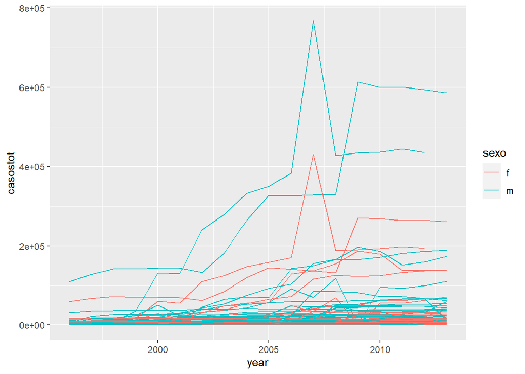

```r
casos_who_gp %>% filter(year>1995) %>% unite(country_sex,country,sexo,remove=F) %>%  ggplot(aes(x=year,y=casostot,group=country_sex,color=sexo)) + geom_line()
```

Considero que a visualização pedida é bem pouco informativa e quase sem utilidade.